# BSAN2204

Lecture 2

R and R Studio for Business Analytics

## `R` and R Studio

Last time we briefly introduced to `R` and R Studio, and showed a few small demonstrations of how it can be used. Today we will dive deeper into `R`, beginning with showing how to install both pieces of software.

Recall that `R` is open source statistical programming language. It is widely used in academia and industry whenever robust statistical analysis is required, whilst R Studio is the development environment in which we will interact with `R`.

Given a lot of the work of a business analyst comprising applying statistical methods to data, learning to work with `R` is just one of the many skills that a business analyst should aim to develop.

## Screenshots of `R` and R Studio

[figure not shown]

[figure not shown]

## Where is `R` used?

As open-source (free) software it is widely used in fields of academic research and science. It is also widely used in industry as the core modelling engine inside many commercial products.

Many large organisations also use `R`, including the FAANG companies, banks, IT companies, etc. Some government agencies also use `R`.

[figure not shown]

`R` is used practically anywhere data analytics is a critical component of the business.

## Installing `R`

Installing `R` is straight forward. Go to https://cran.csiro.au/ and follow the links for your operating system.

[figure not shown]

## `R` for windows users:

Select **base**, then download and run the `.exe` and follow the prompts.

[figure not shown]

## `R` for mac users

Select the `*.pkg` appropriate for your processor. The first option is for newer macs. The second option is for older macs.

[figure not shown]

If you are not sure, Click the Apple icon in the top left corner of the screen and select About This Mac. If you see “Chip” it means you have an Apple M Chip (newer), if you see “Processor” you have an Intel processor (older).

## `R` for Linux users

Open your console and install using:

`sudo apt-get install r-base`

## `R` history

`R` was developed in the early 1990s by two academics at the the University of Auckland (Ross Ihaka and Robert Gentleman). It was originally developed for the purpose of teaching introductory statistics. `R` is based on the language `S` which goes back to the 1970s.

Given the origins of `R` go back almost **50 years** and that it is still being actively developed, `R` is considered to be a very reliable language to learn in terms of remaining contemporary and relevant into the future.

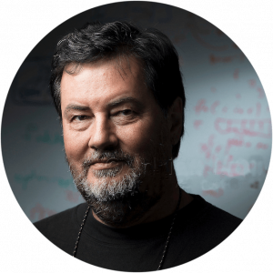

[figure not shown]

## A quick look at `R` (by itself)

[figure not shown]

Running `R` on its own (without R Studio) uses very little memory and CPU, although almost no users would do this unless they are running automated processes which do not require any user input (in which case python would probably be preferred!). `R` can also be run directly from your console.

## What about python?

Compared to `R`, python is a much more general purpose language not specifically tailored to run statistical analysis, but it a very versatile and well suited to perform many of the same tasks that `R` can do.

`R` and python are often used interchangeably or in hybrid. R Studio can be used to edit and run python code. The `reticulate` package can used to embed python code within `R` code, whilst the `rpy2` package allows python to call `R` functions.

[figure not shown]

## What about Excel?

Spreadsheets have their time and place, for example to perform some quick once-off calculations. When precision, reproducibility, and scalability are required spreadsheets should be avoided.

Despite the above statement, many organisations will rely heavily on convoluted interconnected spreadsheets. The reason for this is partly due to inertia (“this is just the way we do it”), and partly due to lack of skill.

If a business deals with large datasets, repetitive analysis, or advanced modelling, they should transition away from spreadsheets.

## Advantages of `R`

`R` is particularly well suited to working with very large datasets. Excel spreadsheets by comparison are limited to only about 1 million rows, and about 16,000 columns. By contrast, the row limit of a data frame in `R` is about 2 billion (2000x more).

In business analytics contexts, it is entirely feasible for firms to be dealing with 10s of millions of rows within a dataset on a routine basis. Consider a customer database of a telecommunications provider, or the databases within the Australian Tax Office.

## Spotify Example

Spotify hosts over 100 million tracks, nearly 7 million podcast titles, and 350,000 audiobooks on its streaming platform for its over 276 million users ([source](https://newsroom.spotify.com/company-info/#:~:text=Today%2C%20more%20listeners%20than%20ever,a%20la%20carte%20on%20Spotify.)).

It will be essential to rely on `R` or python when working at these scales.

[figure not shown]

The Million Song Dataset (MSD) used for the assignments in BSAN2204 is extracted from Spotify catalogue of millions of songs. It contains a small subset of their over 100 million song database. The `MSD` has “just” 1 million rows and 18 columns, so in theory it could be opened in Excel although in practice doing so would be impractical.

## Other software platforms

[figure not shown]

## AI Driven Cloud Based Platforms

[figure not shown]

## Platforms with `R` integration

**Qlik Sense** supports `R` through its Advanced Analytics Integration (AAI). You can send expressions from Qlik to an `R` backend (via server-side extensions or OpenCPU) and return results into visualisations.

**Tableau Online (Salesforce)** connects to `R` using the `Rserve` package. This allows you to call `R` functions, libraries, and models directly from Tableau calculated fields, enabling advanced statistical analysis and predictive modelling.

## Data structures in `R`

R provides a rich set of data structures to organise, manipulate, and analyse data efficiently. Understanding these structures is essential for writing clean, modular, and reproducible code.

The types include vectors, matrices, arrays, data frames, factors and tibbles. All of these data structures are essentially **lists**, or “lists of lists”.

In `R` terminology these are structures are usually referred to as “objects”, whilst the names of elements within these objects are referred to as “variables” (for example, the columns of a data frame).

## Types of data structures in `R`

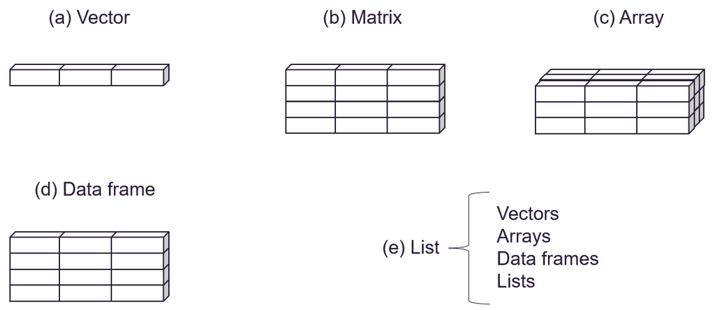

## Object oriented, functional programming

`R` is designed around object-oriented principles, but blends with functional programming.

In `R` *everything is an object*. Vectors, data frames, the output from models, are all objects. Meanwhile, as we will see often throughout the course, variables are simply *names* for objects. For example, the code below creates and stores object with the name “BSAN_courses” into the environment of an `R` session.

```r
BSAN_courses <- c("BSAN2201", "BSAN2204", "BSAN2205",
                  "BSAN3204", "BSAN3209", "BSAN3210",
                  "BSAN3212", "BSAN4201", "BSAN4204")
```

Here I have assigned a vector of course names (characters) to an object called `BSAN_courses`.

## Vectors

Vectors are the most fundamental data structure in `R`. They have several defining characteristics that make them powerful and versatile for data analysis and manipulation (but these can also be the source of errors and frustration to those used to working with spreadsheets!).

All elements in a vector must be of the same type. When different types of data are included in a vector, `R` will automatically coerce the vector to the most flexible type. Vectors are one-dimensional linear sequences of elements (they do not have rows or columns).

Vectors can be created using: `c()` for combining elements, `seq()` for sequences, `rep()` for repetition, `:` for ranges (e.g., 1:5 for “1 to 5”)

## Example of vectors in `R`:

```r
# Creating a numeric vector
v1 <- c(1, 2, 3, 4)

# Creating a character vector
v2 <- c("apple", "banana", "cherry", "blueberry")

# Mixed types (coerced to character)
v3 <- c("apple", 42, TRUE)  # All become character
```

When vectors are combined together, for example using a row binding function `rbind()`, the result is the creation of a matrix. Each row of the matrix will be named according to original vector it came from.

```r
v1_v2 <- rbind(v1, v2)
print(v1_v2)
```

```
   [,1]    [,2]     [,3]     [,4]
v1 "1"     "2"      "3"      "4"
v2 "apple" "banana" "cherry" "blueberry"
```

## Matrices

Matrices are a core two-dimensional data structure used for numerical and statistical computations. They extend the concept of vectors by adding a second dimension (rows and columns) while retaining the requirement that all elements must be of the same type.

The data within a matrix are accessed by using `[row, column]` positions.

We use matrices for various purposes. For example, when visualising data, a matrix can be used to specify a grid layout of multiple plots.

## Examples of matrices in `R`:

```r
# Creating a 3x3 matrix filled by row
m <- matrix(1:9, nrow = 3, ncol = 3, byrow = TRUE)
m
```

```
     [,1] [,2] [,3]
[1,]    1    2    3
[2,]    4    5    6
[3,]    7    8    9
```

```r
# Access element at row 2, column 3
m[2, 3]  # Returns 6
```

```
[1] 6
```

## Usign matrices to control plot layout

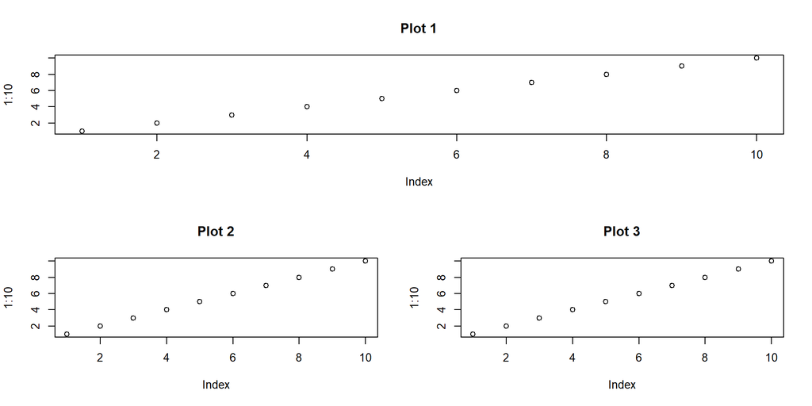

```r
layout_matrix <- matrix(c(1, 1, 2, 3), nrow = 2, byrow = TRUE)
layout(layout_matrix)

plot(1:10, main = "Plot 1")  # spans top row
plot(1:10, main = "Plot 2")  # bottom-left
plot(1:10, main = "Plot 3")  # bottom-right
```

## Arrays

Arrays are a multi-dimensional extension of vectors and matrices, designed to store homogeneous data across two or more dimensions. A 2D array is the same as a matrix. A 3D array might stack multiple matrices.

Arrays support support element-wise operations (e.g., addition, multiplication). W can apply functions like `sum()` or `mean()` across dimensions using functions like `apply()`.

Look at the help documentation for `apply()` before running this example.

## `apply()` documentation

To view the documentation (help file) for any package, use either the `?` operator or the `help()` function.

Option 1:

```r
?apply
```

Options 2:

```r
help(apply)
```

Option 3:

Alternatively, you can navigate to the documentation for any package within the graphical interface of R Studio.

## Examples of arrays in `R`:

```r
# Creating an array with 2 rows, 3 columns and 2 layers (matrices)
# It is a 2 × 3 × 2 array, which holds 12 elements in total.
arr <- array(1:12, dim = c(2, 3, 2))
arr
```

```
, , 1

     [,1] [,2] [,3]
[1,]    1    3    5
[2,]    2    4    6

, , 2

     [,1] [,2] [,3]
[1,]    7    9   11
[2,]    8   10   12
```

```r
# Access element at row 1, column 2, dimension 2
arr[1, 2, 2]  # Returns 9
```

```
[1] 9
```

## Using `apply()`

When `apply()` is *applied* to the array called `arr`. The second argument is the MARGIN which is “a vector giving the subscripts which the function will be applied over” [..] “for a matrix 1 indicates rows, 2 indicates columns, c(1, 2) indicates rows and columns”. FUN is “the function to be applied”.

```r
# Apply sum across rows (dimension 1)
apply(arr, 2, sum)
```

```
[1] 18 26 34
```

The above calculates the sum of each column. MARGIN = 2 (columns), FUN = sum (summation).

## Data Frames

Data frames are one of the most commonly used data structures for storing and manipulating data.

A data frame is essentially a table where each column can contain different types of data (e.g., numeric, character, logical). Each column in a data frame is like a vector, and each row is an observation or data point. Columns can hold different data types (numeric, character, factor, etc.). In a business analytics context, the rows of a data frame typically represent individual observations.

In most business analytics situations, you will be provided a dataset (such as a `.Rdata` file) which contains a data frame).The `data.frame()` function is used to combined different data types (vectors, matrices, etc.) together into a data frame table.

## Examples of data frames `R`:

```r
patientID <- c(1, 2, 3, 4)
age <- c(25, 34, 28, 52)
diabetes <- c("Type1", "Type2", "Type1", "Type1")
status <- c("Poor", "Improved", "Excellent", "Poor")

patientdata <- data.frame(patientID, age, diabetes, status)
```

Because data frames resemble tables, it is the data structure most commonly used by *tabulation packages* in R Markdown which output the contents of a data frame to generated reports in neat and tidy formats.

The examples on the next slide compare the **raw console output** of the contents of `patientdata`, with the formatted output generated using the `kable()` function from the `knitr` to create a nice professionally formatted table.

## Raw console output vs Formatted Table

```r
patientdata
```

```
  patientID age diabetes    status
1         1  25    Type1      Poor
2         2  34    Type2  Improved
3         3  28    Type1 Excellent
4         4  52    Type1      Poor
```

versus

```r
library(knitr)
kable(patientdata)
```

| patientID | age | diabetes | status |
| --- | --- | --- | --- |
| 1 | 25 | Type1 | Poor |
| 2 | 34 | Type2 | Improved |
| 3 | 28 | Type1 | Excellent |
| 4 | 52 | Type1 | Poor |

## Lists

Lists are one of the most flexible and powerful data structures in the `R`, especially useful when dealing with different data types. Lists essentially combine all the previously mentioned data structures.

Many analysis methods will output results in the form of a list. For example, a regression model estimated using the `lm()` function will return a list with with all the different components of the model like coefficients, residuals, etc. These elements can all be called upon for further post-hoc analysis.

## Example of lists in `R`:

```r
model <- lm(mpg ~ wt, data = mtcars)
str(model)  # Returns a list with components like coefficients, residuals, etc.
```

```
List of 12
 $ coefficients : Named num [1:2] 37.29 -5.34
  ..- attr(*, "names")= chr [1:2] "(Intercept)" "wt"
 $ residuals    : Named num [1:32] -2.28 -0.92 -2.09 1.3 -0.2 ...
  ..- attr(*, "names")= chr [1:32] "Mazda RX4" "Mazda RX4 Wag" "Datsun 710" "Hornet 4 Drive" ...
 $ effects      : Named num [1:32] -113.65 -29.116 -1.661 1.631 0.111 ...
  ..- attr(*, "names")= chr [1:32] "(Intercept)" "wt" "" "" ...
 $ rank         : int 2
 $ fitted.values: Named num [1:32] 23.3 21.9 24.9 20.1 18.9 ...
  ..- attr(*, "names")= chr [1:32] "Mazda RX4" "Mazda RX4 Wag" "Datsun 710" "Hornet 4 Drive" ...
 $ assign       : int [1:2] 0 1
 $ qr           :List of 5
  ..$ qr   : num [1:32, 1:2] -5.657 0.177 0.177 0.177 0.177 ...
  .. ..- attr(*, "dimnames")=List of 2
  .. .. ..$ : chr [1:32] "Mazda RX4" "Mazda RX4 Wag" "Datsun 710" "Hornet 4 Drive" ...
  .. .. ..$ : chr [1:2] "(Intercept)" "wt"
  .. ..- attr(*, "assign")= int [1:2] 0 1
  ..$ qraux: num [1:2] 1.18 1.05
  ..$ pivot: int [1:2] 1 2
  ..$ tol  : num 1e-07
  ..$ rank : int 2
  ..- attr(*, "class")= chr "qr"
 $ df.residual  : int 30
 $ xlevels      : Named list()
 $ call         : language lm(formula = mpg ~ wt, data = mtcars)
 $ terms        :Classes 'terms', 'formula'  language mpg ~ wt
  .. ..- attr(*, "variables")= language list(mpg, wt)
  .. ..- attr(*, "factors")= int [1:2, 1] 0 1
  .. .. ..- attr(*, "dimnames")=List of 2
  .. .. .. ..$ : chr [1:2] "mpg" "wt"
  .. .. .. ..$ : chr "wt"
  .. ..- attr(*, "term.labels")= chr "wt"
  .. ..- attr(*, "order")= int 1
  .. ..- attr(*, "intercept")= int 1
  .. ..- attr(*, "response")= int 1
  .. ..- attr(*, ".Environment")=<environment: R_GlobalEnv>
  .. ..- attr(*, "predvars")= language list(mpg, wt)
  .. ..- attr(*, "dataClasses")= Named chr [1:2] "numeric" "numeric"
  .. .. ..- attr(*, "names")= chr [1:2] "mpg" "wt"
 $ model        :'data.frame':  32 obs. of  2 variables:
  ..$ mpg: num [1:32] 21 21 22.8 21.4 18.7 18.1 14.3 24.4 22.8 19.2 ...
  ..$ wt : num [1:32] 2.62 2.88 2.32 3.21 3.44 ...
  ..- attr(*, "terms")=Classes 'terms', 'formula'  language mpg ~ wt
  .. .. ..- attr(*, "variables")= language list(mpg, wt)
  .. .. ..- attr(*, "factors")= int [1:2, 1] 0 1
  .. .. .. ..- attr(*, "dimnames")=List of 2
  .. .. .. .. ..$ : chr [1:2] "mpg" "wt"
  .. .. .. .. ..$ : chr "wt"
  .. .. ..- attr(*, "term.labels")= chr "wt"
  .. .. ..- attr(*, "order")= int 1
  .. .. ..- attr(*, "intercept")= int 1
  .. .. ..- attr(*, "response")= int 1
  .. .. ..- attr(*, ".Environment")=<environment: R_GlobalEnv>
  .. .. ..- attr(*, "predvars")= language list(mpg, wt)
  .. .. ..- attr(*, "dataClasses")= Named chr [1:2] "numeric" "numeric"
  .. .. .. ..- attr(*, "names")= chr [1:2] "mpg" "wt"
 - attr(*, "class")= chr "lm"
```

## Accessing part of a list

The first element in the list on the previous slide is a *named* vector. A named vector in `R` is a regular vector where each element has an associated name that helps access values.

We can output this named vector using the `$` operator:

```r
model$coefficients
```

```
(Intercept)          wt
  37.285126   -5.344472
```

If we want to extract a specific part of this vector, we can use `[]`:

```r
model$coefficients[2]
```

```
       wt
-5.344472
```

If we just want the value, and not its name, we can use `unname()`:

```r
unname(model$coefficients[2])
```

```
[1] -5.344472
```

## Using `[]` and `:`

Row/column coordinates placed inside `[]` (square brackets) will return the data at that location. For example, to retrieve the data on the 2nd row and 4th column of the data frame, use:

```r
patientdata[2,4]
```

```
[1] "Improved"
```

Or, to print the 2nd row and 2nd to 4th columns of the data frame to the console, use:

```r
patientdata[2,2:4]
```

```
  age diabetes   status
2  34    Type2 Improved
```

## Using `$` and names

Instead of using numerical values to refer to a location, we can also used named variables. For a single variable the dollar sign `$` operator can be used. For multiple variables, we can combine a list of variables inside `[]` square brackets using the combine `c()` function.

Try the following:

```r
patientdata$age
```

```
[1] 25 34 28 52
```

```r
patientdata[c("diabetes","status")]
```

```
  diabetes    status
1    Type1      Poor
2    Type2  Improved
3    Type1 Excellent
4    Type1      Poor
```

## R Studio (aka Posit)

R Studio is an Integrated Development Environment (IDE) made specifically for `R`. Working with `R` in an IDE has many benefits.

A good analogy is to compare writing an essay in Notepad (Windows) or TexEdit (Mac) to a fully fledged word processor like Microsoft Word. R Studio is a fully fledged editor with many features which make the process of working with `R` a lot easier.

R Studio has 4 main windows which help to organise projects much easier than just having a console. The script editor window in particular features colour coding and auto-completion options.

## Installing R Studio

Installing R Studio is straight forward. Go to https://posit.co/download/rstudio-desktop/ and follow the links for your operating system.

[figure not shown]

## R Studio history

Early versions of R Studio were released in 2011 by Joseph J. Allaire, with the first full version (1.0) released in 2016. Compared to `R`, R Studio is relatively new and continues to release new features regularly (e.g. Copilot AI integration).

The company R Studio changed its name to Posit in 2022, although the IDE retains the name R Studio.

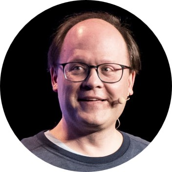

(click to watch a very interesting podcast interview with Allaire on YouTube)

## R Studio rebranding to Posit

R Studio re-branded to Posit in 2022 to reflect its evolution from an `R` centric editor to a broader, language-agnostic platform suitable for a wide variety of data science applications.

The name R Studio is still in use, but will gradually change over time. R Studio (or Posit) has built in support for both `R` and Python, and can be extended through the installation of extensions to support SQL, C/C++, Rust, JavaScript/TypeScript and Lua.

Through using Quarto (like these slides), R Studio/Posit supports creation of multilingual documents.

## Reproducibility

Reproducibility refers to the ability to consistently recreate the results of an analysis using the same data, code, and methods. It ensures transparency, reliability, and trust in computational work.

R Studio enhances the reproducibility of your analysis with its inbuilt tools such as R Markdown and Quarto. These allow code, narrative, and output to coexist within a single document, streamlining the workflow from data import to the final report.

In BSAN2204, you will learn to do analysis with `R` and to how to communicate effectively both *in* and *with* your `R` code based on the principals of reproducible analysis.

## R Studio panels

### Source

The Source Pane is the top-left panel in R Studio by default. It is where `R` is written/edited, and where projects in `R` are are managed. It supports multiple file types, the most basic of which is are `.r` files. In BSAN2204, we will primarily create `.Rmd` files (R Markdown files), which we later render into `.html` reports.

The source pane is tabbed, allowing for multiple files to be opened at once. It supports syntax highlighting, which improves the readability of `R` code. Other handy features include line numbers and automatic error detection (e.g., missing closing parentheses).

## R Studio panels

### Console

The Console Pane is typically located in the bottom-left of the R Studio interface. It is where `R` code is executed. Code can either executed interactively, line by line or in chunks, and where you see immediate (unformatted) output, errors, warnings and messages.

Commands can be typed directly into the console. This is ideal for quick calculations, testing a function, or installing packages.

Console output should only ever read by the analyst. `R` functions which generate outputs intended to go into a rendered R Markdown report should always be formatted using a tabulation or data visualisation tool.

## Raw `R` console outputs

Output within the console pane is rendered as mono spaced plain text, with no colour coding, indentation, or visual hierarchy, for example:

```r
summary(mtcars)
```

```
      mpg             cyl             disp             hp
 Min.   :10.40   Min.   :4.000   Min.   : 71.1   Min.   : 52.0
 1st Qu.:15.43   1st Qu.:4.000   1st Qu.:120.8   1st Qu.: 96.5
 Median :19.20   Median :6.000   Median :196.3   Median :123.0
 Mean   :20.09   Mean   :6.188   Mean   :230.7   Mean   :146.7
 3rd Qu.:22.80   3rd Qu.:8.000   3rd Qu.:326.0   3rd Qu.:180.0
 Max.   :33.90   Max.   :8.000   Max.   :472.0   Max.   :335.0
      drat             wt             qsec             vs
 Min.   :2.760   Min.   :1.513   Min.   :14.50   Min.   :0.0000
 1st Qu.:3.080   1st Qu.:2.581   1st Qu.:16.89   1st Qu.:0.0000
 Median :3.695   Median :3.325   Median :17.71   Median :0.0000
 Mean   :3.597   Mean   :3.217   Mean   :17.85   Mean   :0.4375
 3rd Qu.:3.920   3rd Qu.:3.610   3rd Qu.:18.90   3rd Qu.:1.0000
 Max.   :4.930   Max.   :5.424   Max.   :22.90   Max.   :1.0000
       am              gear            carb
 Min.   :0.0000   Min.   :3.000   Min.   :1.000
 1st Qu.:0.0000   1st Qu.:3.000   1st Qu.:2.000
 Median :0.0000   Median :4.000   Median :2.000
 Mean   :0.4062   Mean   :3.688   Mean   :2.812
 3rd Qu.:1.0000   3rd Qu.:4.000   3rd Qu.:4.000
 Max.   :1.0000   Max.   :5.000   Max.   :8.000
```

This prints the result generated by `summary()` as raw console output.

## R Studio panels

### Environment/History

The Environment tab shows all the objects currently loaded into your `R` session. It displays object names, their type and a brief summary. For very large projects, the search bar comes in handy to locate objects.

Some useful GUI features in the environment pane include the broom which can be used to clear the environment of all objects, the save workspace button (used to save the environment as a `.Rdata` file), and the Import Dataset button (especially useful for files from other software like Excel or SPSS).

The history tab records a log of every command entered into the console during a session.

## R Studio panels

### Files/Plots/Packages/Help/Viewer/Presentation

This pane is typically located in the bottom-right corner. This pane supports file management, visualisation, package libraries, documentation access, and interactive content rendering.

This presentation is the `.html` file rendered from the `.Qmd` (Quarto Markdown) file located in the Source pane. I am presenting using the Presentation pane in R Studio, but it can also be opened in an web browser.

During an `R` session you will regularly come to this pane to install packages, read package documentation when seeking help to troubleshooting errors, and to look at plots before deciding whether or not to include them in a report.

## Keyboard shortcuts in R Studio

| Action | Windows/Linux | Mac |
| --- | --- | --- |
| Run current line or selection | `Ctrl Enter` | `Cmd Enter` |
| Move lines up/down | `Alt Up / Down` | `Option Up / Down` |
| Insert code chunk (R Markdown/Quarto) | `Ctrl Alt + I` | `Cmd Option I` |
| Knit document | `Ctrl Shift + K` | `Cmd Shift K` |
| Insert assign operator `<-` | `Alt -` | `Option -` |
| Insert Pipe operator `\|>` | `Ctrl Shift + M` | `Cmd Shift M` |

My favourite usability feature is holding down `Alt` (Windows) or `Option` (Mac) in the Source pane to enable a *multi-line cursor* to edit multiple lines at once.

There are many other short cuts to discover! (See: `Alt + Shift + K`)

## `R` Packages

`R` comes preloaded with many “base” packages, but very commonly we will want to work with customised packages that have been contributed to by the open-source community.

Packages can be installed from the Packages tab. When installing a package this way, R Studio will send a `install.packages()` command to the console.

You should avoid ever including a `install.packages()` command inside any `.r` or `.Rmd` file as doing so will lead you (or other users) to update and re-install packages each time the file is run!

## The CRAN

The “CRAN” is the **Comprehensive R Archive Network**. It is the official repository for `R` packages and one of the most important resources in `R`.

It functions as a globally distributed network of servers that hosts 10s of thousands of `R` packages, along with their documentation and source code. Every package submitted to CRAN must pass a series of automated checks to ensure it meets strict standards for reliability, compatibility, and reproducibility. This process is as difficult, if not more difficult, than publishing an academic paper!

## Installing packages

Installing packages in `R` can be done one of several ways. When using R Studio, and especially when authoring R Markdown documents, the recommended approach is to use the R Studio GUI.

Within R Studio, navigate to the **Packages** tab to see the library of currently installed packages. Packages which are currently loaded will have ticked, whilst packages available to load will be unticked.

To install a package from this interface, simply click on “Install” and type the package name sought after.

## `install.packages()`

Using the method described on the previous page will result in the `install.packages()` command being executed in the console window. This is a one time operation that does not need to be repeated, except for when wanting to update to newer version of the package.

For reasons which will become apparent later after we introduce R Markdown, the `install.packages()` command should **not** be included as part of evaluated code within a project as doing so would result in the package being re-installed (updated) every time the document is generated.

## Working directories

Each `R` session has a defined working directory. An `R` working directory is the folder location on the file system from which `R` reads and writes files by default during an `R` session.

R Studio provides various ways to set a working directory using its GUI, which all result in the `setwd()` command being executed in the console window. This command should also **not** be included as part of evaluated code within a project as doing so would result in the file attempting to navigate to a location that does not exist (e.g., when run on a different computer).

Task: Check your current working directory from the console window using `getwd()`. If it is not your `.../BSAN2204/` folder, then use the R Studio GUI to set to the correct location.

## Importing data into `R`

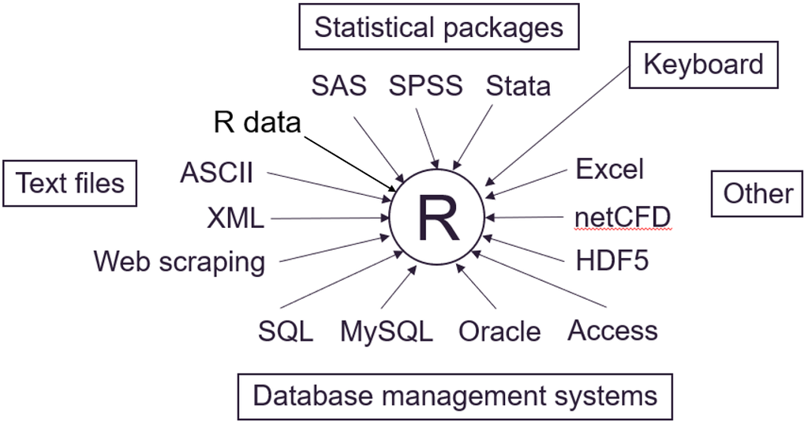

## Using `load()`

The function `load()` is used to reload datasets which were created in `R`. The `MSD.Rdata` file for example, is a file generated using the `save()` function. It may contain multiple objects (e.g., multiple data frames, values, etc.)

In the case of the `MSD.Rdata` file, this stores a single data frame that was created after downloading and processing data from Spotify.

Using `load()` is the first step of any project that relies on data stored in a `.Rdata` file. Once the data has been loaded into the environment, it can be analysed and explored using the various methods explored today.

## Next session:

In the next session we will cover how to use R Markdown to format reports generated using `R`. This will begin with a discussion on the motivations for generating reports this way, as opposed to “writing” documents using word processors.

We will focus on how to structure these documents, placing emphasis on how to control the appearance of the rendered outputs as `.html` files.

We will revisit some of the basics covered today, seeing how they are applied within the context of a R Markdown document used to generate a business analytics report.

## Questions?

If you have any further questions after class, please see me during my consultation time by booking a time via the links available on BlackBoard.

Thank you!